# `rromeo` – an R interface for SHERPA/RoMEO API

[figure not shown]

`rromeo` is an R client for the [SHERPA/RoMEO API](http://www.sherpa.ac.uk/romeo/index.php?la=en&fIDnum=&mode=simple). SHERPA/RoMEO is a database that gives information on editorial policies of scientific journals regarding the archival of preprint, postprint and publishers’ manuscripts. `rromeo` is aimed at scientists interested in archival practices of scientific journals, such as professionals of [scientometrics](https://en.wikipedia.org/wiki/Scientometrics) but also at scientist of specific fields interested in the practices of their fields.

## Install

`rromeo` is not yet on CRAN but you can install the development version of `rromeo` with:

```r
# install.packages("remotes")
remotes::install_github("Rekyt/rromeo")
```

## API Key

Note that SHERPA/RoMEO lets you run 500 requests per day per IP address, by [registering for a free API key](http://www.sherpa.ac.uk/romeo/apiregistry.php) you can bypass this limit.

`rromeo` can use your registered SHERPA/RoMEO API key; you can either pass it as a string when querying the data with the argument `key`:

```r
rr_journal_name("Journal of Geology", key = "Iq83AIL5bss")
```

or you can specify the environment variable `SHERPAROMEO_KEY` in an `.Rprofile` or in an `.Renviron` file and `rromeo` will automatically retrieve the API key.

## Usage

`rromeo` contains functions to retrieve data from the SHERPA/RoMEO API (for a complete overview please refer to the [vignette](https://ropensci.github.io/rromeo/articles/rromeo.html)). The data is released under the [Creative Commons Attribution-NonCommercial-ShareAlike 2.5 (CC BY-NC-SA 2.5) license](https://creativecommons.org/licenses/by-nc-sa/2.5/). A suggestion of citation is included in `rromeo` via `citation("rromeo")`.

`rromeo` functions are prefixed with `rr_` such as `rr_journal_name()` that lets you retrieve a journal policy information using the title of a journal:

```r
rromeo::rr_journal_name("Journal of Biogeography", qtype = "exact")
```

```
#>                     title      issn romeocolour preprint  postprint    pdf
#> 1 Journal of Biogeography 0305-0270      yellow      can restricted cannot
#>   pre_embargo post_embargo pdf_embargo
#> 1        <NA>    12 months        <NA>
```

the `qtype` argument indicates the type of query to make (`exact` for exact matching of the title, `contains` for partial matching and `starts with` to match only the beginning of the title).

You can also retrieve a journal information using its ISSN:

```r
rromeo::rr_journal_issn("0305-0270")
```

```
#>                     title      issn romeocolour preprint  postprint    pdf
#> 1 Journal of Biogeography 0305-0270      yellow      can restricted cannot
#>   pre_embargo post_embargo pdf_embargo
#> 1        <NA>    12 months        <NA>
```

`rromeo` also provides a function to retrieve information based on publisher ID `rr_publisher()`.

SHERPA/RoMEO provides a synthetic “colour” for each journal, the colour summarizes the editorial policy of a journal:

[output not shown]

(Table taken from http://www.sherpa.ac.uk/romeo/definitions.php#colours)

`rromeo` lets you retrieve the policies of all journals of a given colour using the function `rr_romeo_colour()` (**NOTE:** this function can be slow as there many journals to retrieve):

```r
green_journals = rromeo::rr_romeo_colour("green")
green_journals[8:12,]
```

```
#>    romeoid                                                   publisher
#> 8     1128 Association for Information Science and Technology (ASIS&T)
#> 9     1937                                       University of Arizona
#> 10    2951                               Geological Society of America
#> 11    2521                              University of California Press
#> 12    2306                                  Optical Society of America
#>                  alias romeocolour preprint postprint        pdf
#> 8              JASIS&T       green      can       can     cannot
#> 9          Radiocarbon       green      can       can restricted
#> 10           GSA Today       green      can       can        can
#> 11            Collabra       green      can       can        can
#> 12 No Paid Open Access       green      can       can     cannot
```

## Dependency network (Imports only)

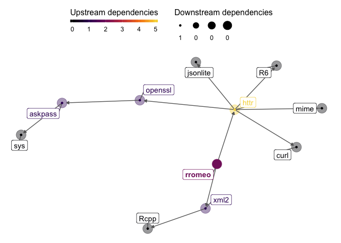

## Dependency network (Imports and Suggests)

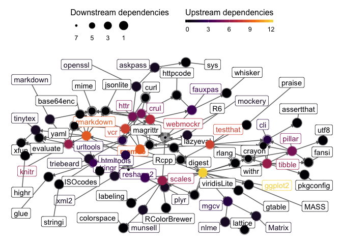

## Contributing to `rromeo`

We welcome contribution to `rromeo`! Please read the contribution guidelines if you want to contribute, as well as the below-mentioned Code of Conduct.

## Code of Conduct

Please note that the `rromeo` project is released with a Contributor Code of Conduct. By contributing to this project, you agree to abide by its terms.

[figure not shown]